# 1 Gapminder revisited

Data: -[data in Gapminder World](https://www.gapminder.org/data/) - Life expectancy at birth (life_expectancy_years.csv) - GDP per capita in constant 2010 US$ (https://data.worldbank.org/indicator/NY.GDP.PCAP.KD) - Female fertility: The number of babies per woman (https://data.worldbank.org/indicator/SP.DYN.TFRT.IN) - Primary school enrollment as % of children attending primary school (https://data.worldbank.org/indicator/SE.PRM.NENR) - Mortality rate, for under 5, per 1000 live births (https://data.worldbank.org/indicator/SH.DYN.MORT) - HIV prevalence (adults_with_hiv_percent_age_15_49.csv): The estimated number of people living with HIV per 100 population of age group 15-49.

You must use the `wbstats` package to download data from the World Bank. The relevant World Bank indicators are `SP.DYN.TFRT.IN`, `SE.PRM.NENR`, `NY.GDP.PCAP.KD`, and `SH.DYN.MORT`

```r
# load gapminder HIV data
hiv <- read_csv("adults_with_hiv_percent_age_15_49.csv")
life_expectancy <- read_csv("life_expectancy_years.csv")

# get World bank data using wbstats
indicators <- c("SP.DYN.TFRT.IN","SE.PRM.NENR", "SH.DYN.MORT", "NY.GDP.PCAP.KD")


library(wbstats)

worldbank_data <- wb_data(country="countries_only", #countries only- no aggregates like Latin America, Europe, etc.
                          indicator = indicators,
                          start_date = 1960,
                          end_date = 2016)

# get a dataframe of information regarding countries, indicators, sources, regions, indicator topics, lending types, income levels,  from the World Bank API
countries <-  wbstats::wb_cachelist$countries
```

We joined the 3 dataframes (life_expectancy, worldbank_data, and HIV) into one.

```r
glimpse(worldbank_data)
```

```
## Rows: 12,369
## Columns: 8
## $ iso2c          <chr> "AW", "AW", "AW", "AW", "AW", "AW", "AW", "AW", "AW", …
## $ iso3c          <chr> "ABW", "ABW", "ABW", "ABW", "ABW", "ABW", "ABW", "ABW"…
## $ country        <chr> "Aruba", "Aruba", "Aruba", "Aruba", "Aruba", "Aruba", …
## $ date           <dbl> 1960, 1961, 1962, 1963, 1964, 1965, 1966, 1967, 1968, …
## $ NY.GDP.PCAP.KD <dbl> NA, NA, NA, NA, NA, NA, NA, NA, NA, NA, NA, NA, NA, NA…
## $ SE.PRM.NENR    <dbl> NA, NA, NA, NA, NA, NA, NA, NA, NA, NA, NA, NA, NA, NA…
## $ SH.DYN.MORT    <dbl> NA, NA, NA, NA, NA, NA, NA, NA, NA, NA, NA, NA, NA, NA…
## $ SP.DYN.TFRT.IN <dbl> 4.82, 4.66, 4.47, 4.27, 4.06, 3.84, 3.62, 3.42, 3.23, …
```

```r
life_expectancy_long<- life_expectancy %>%
 pivot_longer(c(2:302),
              names_to = "year",
              values_to = "Life_Expectancy")


hiv_long <- hiv %>%
 pivot_longer(c(2:34),
              names_to = "year",
              values_to = "HIV")

worldbank_data_long <- worldbank_data %>%
select(-iso2c) %>%
  rename(year = date,
         GDP_per_Capita = NY.GDP.PCAP.KD,
         School_enrollement = SE.PRM.NENR,
         Mortality_Rate = SH.DYN.MORT,
         Fertility_Rate = SP.DYN.TFRT.IN)


LE_HIV <-left_join(life_expectancy_long,hiv_long,by =c("country","year"))


LE_HIV$year <- as.double(LE_HIV$year)

library(countrycode)

LE_HIV$iso3c<-countrycode(sourcevar = LE_HIV$country,
                                       origin = "country.name",
                             destination = "iso3c")

total <-left_join(LE_HIV, worldbank_data_long,by =c("iso3c","year"))

total <- total %>%
  select (-country.y, -iso3c) %>%
  rename(country = country.x)


total$region <- countrycode(sourcevar = total$country,
                              origin = "country.name",
                             destination = "region")
```

> By looking at the life_expectancy and hiv data frames, it is clear that data is not organised in a best way. We have added a variable “year” to both data frames to include observations according to each year vertically. Addtitionaly, the datarame “worldbank_data” includes redundant variables such as iso2c and iso3 (indicate country name which is also a variable) which we have removed. Moreover,to make names of the variables easier to understand, we renamed “NY.GDP.PCAP.KD”, “SE.PRM.NENR”, “SH.DYN.MORT”, “SP.DYN.TFRT.IN”.
1. What is the relationship between HIV prevalence and life expectancy? Generate a scatterplot with a smoothing line to report your results. You may find faceting useful

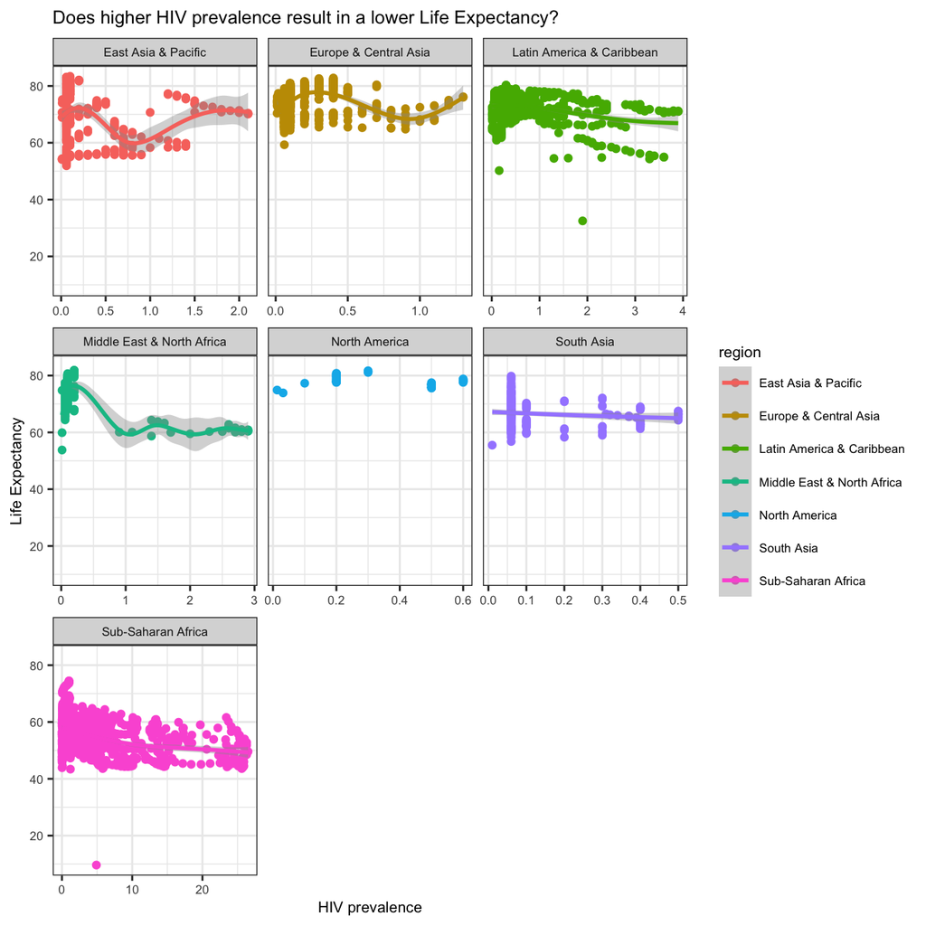

```r
total %>%
  filter(year %in% c(1979:2011)) %>%
ggplot(aes(x=HIV,
           y=Life_Expectancy,
           colour=region))+
  geom_point()+
  geom_smooth()+
  facet_wrap(~region, scales = "free_x")+
  labs(title = "Does higher HIV prevalence result in a lower Life Expectancy?",
             x="HIV prevalence",
             y="Life Expectancy")+
   theme_bw()+
   theme(text = element_text(size=8))+
   NULL
```

> By looking at the “Does higher HIV prevalence result in a lower Life Expectancy?” graph faceted by region, we cannot detect a clear trend, however in Latin America & Carribbean, Middle East & North Africa, South Asia and Sub-Saharan Africa there is a small downward trend, indicating that higher HIV privalence is correlated with lower Life Expectancy.
1. What is the relationship between fertility rate and GDP per capita? Generate a scatterplot with a smoothing line to report your results. You may find facetting by region useful

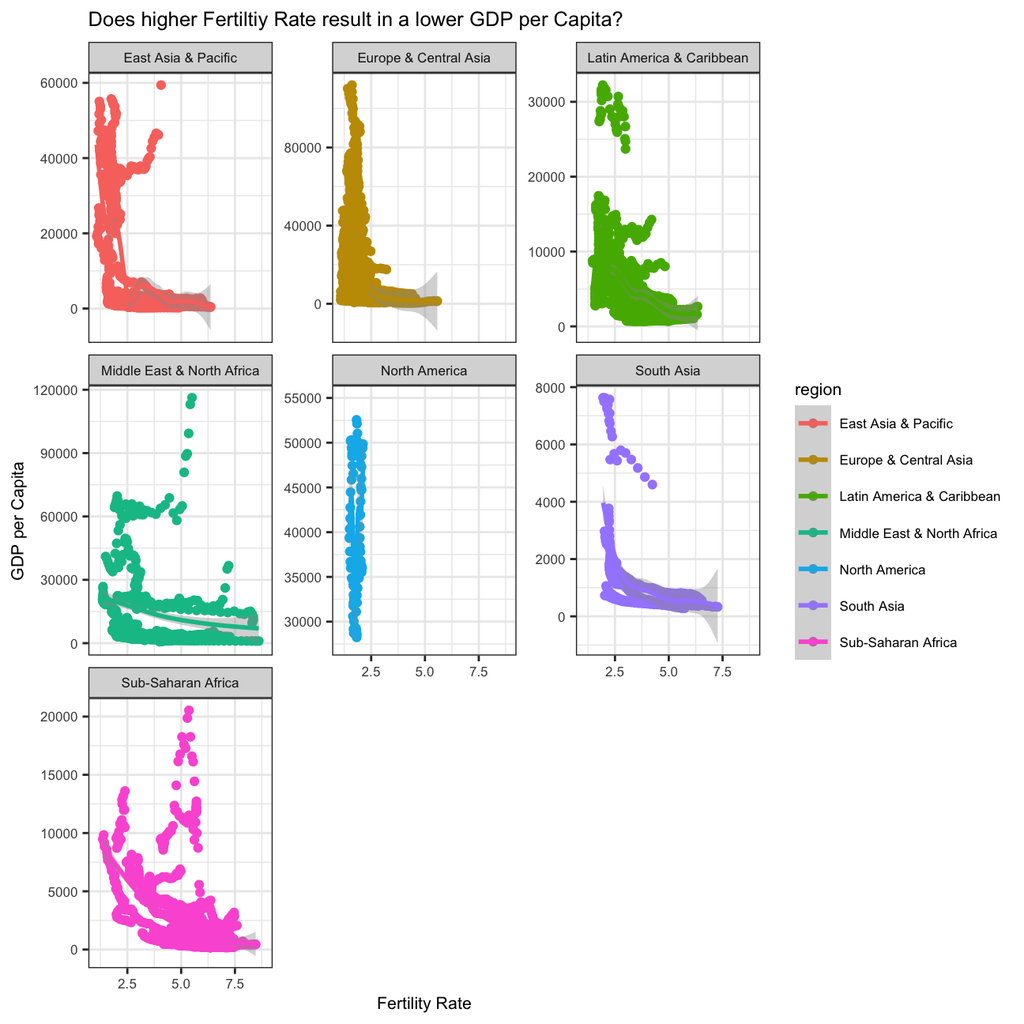

```r
total %>%
  filter(year %in% c(1980:2016)) %>%
ggplot(aes(x=Fertility_Rate,
           y=GDP_per_Capita,
           colour=region))+
  geom_point()+
  facet_wrap(~region, scales = "free_y")+
  geom_smooth()+
  labs(title = "Does higher Fertiltiy Rate result in a lower GDP per Capita?",
         x="Fertility Rate",
         y="GDP per Capita")+
   theme_bw()+
  theme(text = element_text(size=8))+
  NULL
```

> By looking at the “Does higher Fertility Rate result in a lower GDP per Capita?” graph faceted by region, we can see a downward trend, indicating that higher Fertility Rate is correlated with lower GDP per Capita.
1. Which regions have the most observations with missing HIV data? Generate a bar chart (`geom_col()`), in descending order.

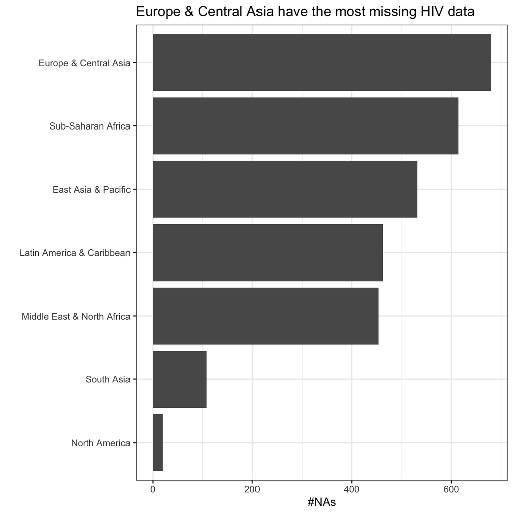

```r
total_NAs <- total %>%
  filter(year %in% c(1979:2011)) %>%
  group_by(region) %>%
  filter(HIV %in% NA) %>%
  count(is.na(HIV)) %>%
  arrange(desc(n)) %>%
  rename(number_of_NAs=n)


ggplot(total_NAs,
       aes(y=reorder(region,number_of_NAs),
           x=number_of_NAs))+
           geom_col()+
labs(title = "Europe & Central Asia have the most missing HIV data",
     subtutle= "Missing HIV data across regions",
         x="#NAs",
         y="")+
  theme_bw()+
  NULL
```

We find the top 5 countries that have seen the greatest improvement, as well as those 5 countries where mortality rates have had the least improvement or even deterioration.

```r
filtered <- total %>%
  filter(region == "South Asia", year == 2015)

glimpse(filtered)
```

```
## Rows: 8
## Columns: 9
## $ country            <chr> "Afghanistan", "Bangladesh", "Bhutan", "India", "M…
## $ year               <dbl> 2015, 2015, 2015, 2015, 2015, 2015, 2015, 2015
## $ Life_Expectancy    <dbl> 61.2, 72.5, 73.5, 68.4, 81.2, 69.6, 66.0, 76.9
## $ HIV                <dbl> NA, NA, NA, NA, NA, NA, NA, NA
## $ GDP_per_Capita     <dbl> 574, 1002, 2781, 1752, 7502, 732, 1081, 3647
## $ School_enrollement <dbl> NA, NA, 88.2, NA, 96.1, 98.1, 61.0, 98.9
## $ Mortality_Rate     <dbl> 70.4, 37.5, 33.1, 43.5, 10.1, 36.2, 76.1, 8.7
## $ Fertility_Rate     <dbl> 4.98, 2.12, 2.04, 2.29, 1.99, 2.10, 3.66, 2.21
## $ region             <chr> "South Asia", "South Asia", "South Asia", "South A…
```

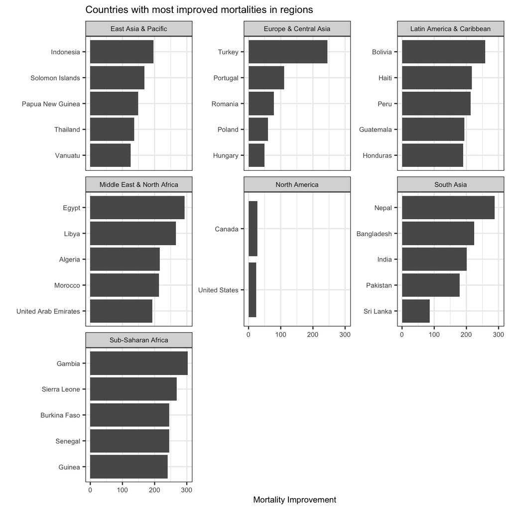

```r
total_MRC1 <- total %>%
  filter(year %in% c(1960:2016)) %>%
  group_by(country) %>%
  mutate(Mortality_Rate_change = first(Mortality_Rate) - last(Mortality_Rate)) %>%
  filter(year %in% 2015) %>%
  group_by(region) %>%
  arrange(Mortality_Rate_change) %>%
               slice_max(Mortality_Rate_change,n=5)

ggplot(total_MRC1,
       aes(x=Mortality_Rate_change,
           y = reorder(country, Mortality_Rate_change)))+
  geom_col()+
  facet_wrap(~region, scales= "free_y","free_x") +
  theme_bw()+
  labs(title="Countries with most improved mortalities in regions",
       x= "Mortality Improvement",
       y="")+
  theme(text = element_text(size=8))+
  NULL
```

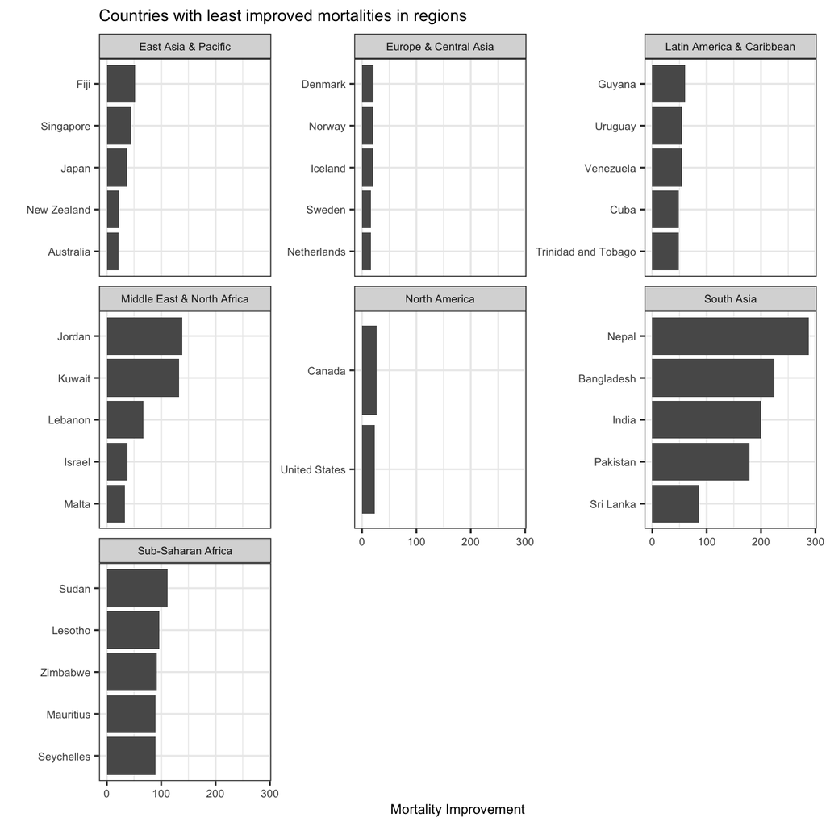

```r
total_MRC2 <- total %>%
  filter(year %in% c(1960:2016)) %>%
  group_by(country) %>%
  mutate(Mortality_Rate_change = first(Mortality_Rate) - last(Mortality_Rate)) %>%
  filter(year %in% 2015) %>%
  group_by(region) %>%
  arrange(Mortality_Rate_change) %>%
               slice_min(Mortality_Rate_change,n=5)

ggplot(total_MRC2,
       aes(x=Mortality_Rate_change,
           y = reorder(country, Mortality_Rate_change)))+
  geom_col()+
  facet_wrap(~region, scales= "free_y","free_x") +
  theme_bw()+
  labs(title="Countries with least improved mortalities in regions",
       x= "Mortality Improvement",
       y="")+
theme(text = element_text(size=8))+
  NULL
```

Is there a relationship between primary school enrollment and fertility rate?

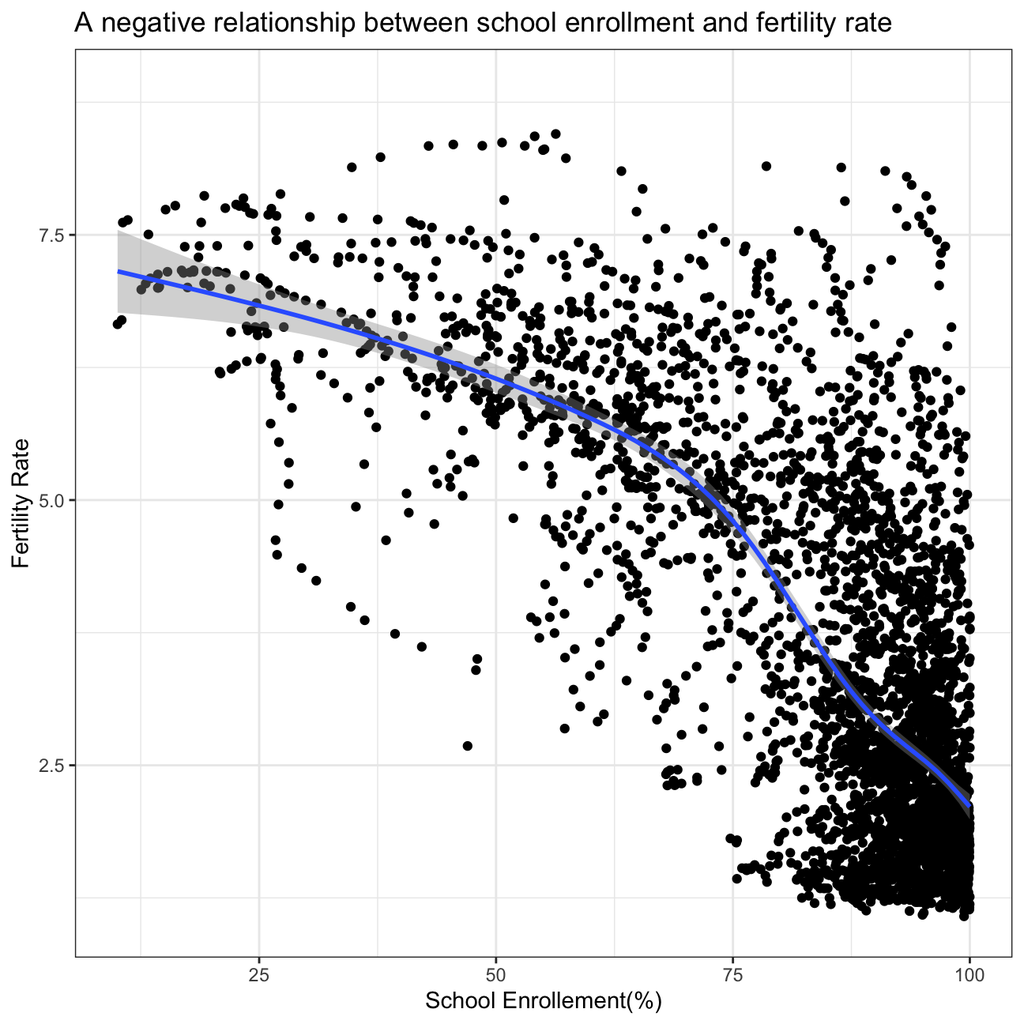

```r
total %>%
  filter(year %in% c(1960:2016)) %>%
ggplot(aes(x=School_enrollement,
           y=Fertility_Rate))+
  geom_point()+
  geom_smooth()+
  labs(title = "A negative relationship between school enrollment and fertility rate",
         x="School Enrollement(%)",
         y="Fertility Rate")+
  theme_bw()+
  NULL
```